# Control Flow

## Java Control Flow

Java, like any programming language, supports both conditional statements and loops to determine the control flow. Control flow - is the way Java makes choices. In Java keywords for control flow are: `if-else if-else, while, do-while, for, return, break and switch`.

### Block scope

Before learning about control statements we need to consider blocks. A block, or compound statement, consists of a number of Java statements, surrounded by the pair of curly braces. Block defines the scope of your variables. Block can be nested inside another block.

```java
public static void main(String[] args) {
    int n = 0;
    // Some code
    {
        // nested block
    }
}
```

You can't use same variable names in nested block:

```java
public static void main(String[] args) {
    int n = 0;
    // Some code
    for (int i = 0; i < 5; i++) {
        int n = 1; // nested block
        System.out.println(n + i);
    }
}
```

```
|           int n = 1; // nested block
variable n is already defined in method main(java.lang.String[])

|   public static void main(String[] args) {
Modifier 'static'  not permitted in top-level declarations, ignored
```

### Conditional Statements

The conditional statement in Java has a form:

```
if (condition) {
    do something
}
```

The condition must be surrounded by parentheses. You can use any number of statements if condition is True. You need to put them in curly braces.

```java
boolean isWeatherGood = true;

if (isWeatherGood) {
    System.out.println("What a lovely day!");
    System.out.println("Let's go for a walk.");
}
```

```
What a lovely day!
Let's go for a walk.
```

```
if (yourSales >= target) {
    performance = "Satisfactory";
    bonus = 100;
}
```

In this code all the statements will be executed when yourSales is greater than or equal to target.

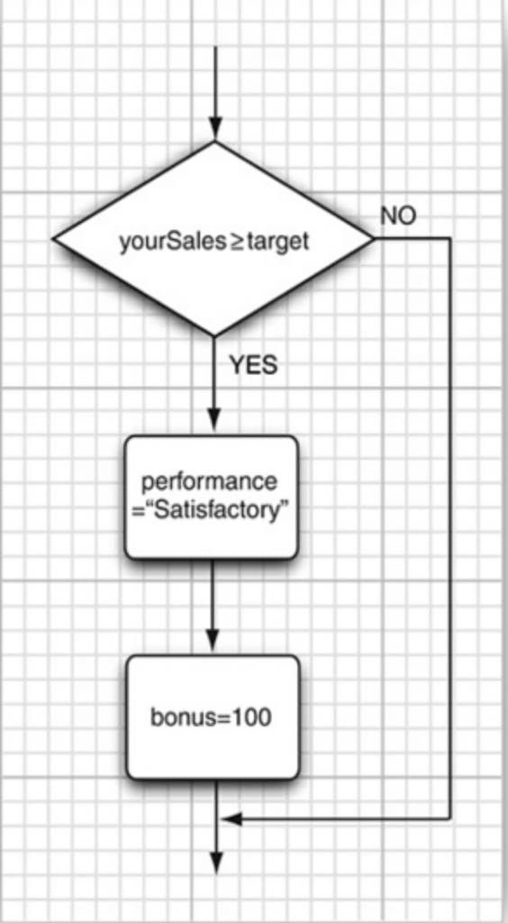

The more general conditions in Java look like this:

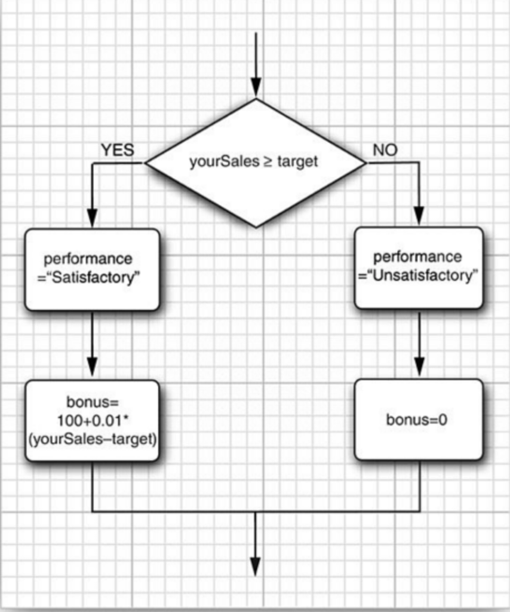

It has two differen flows: `if (condition) statement1 else statement2;`

```java
int yourSales = 1000;
int target = 800;
double bonus = 0;
String performance;

if (yourSales >= target) {
    bonus = 100 + 0.01 * (yourSales - target);
    performance = "Satisfactory";
} else {
    bonus = 0;
    performance = "Unsatisfactory";
}
System.out.println(bonus);
System.out.println(performance);
```

```
102.0
Satisfactory
```

The else part is **optional**.

Let explore more advanced example:

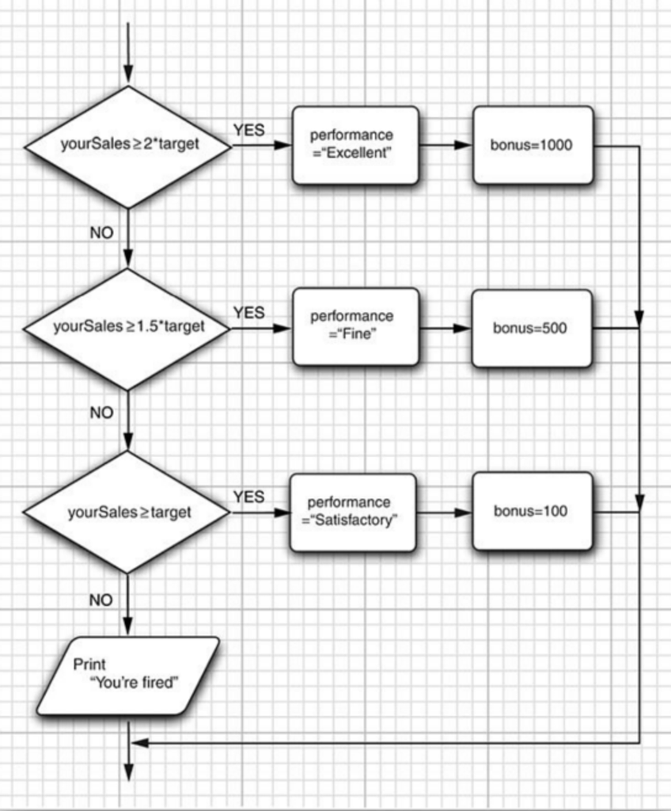

```java
yourSales = 2000;

if (yourSales >= 2 * target) {
    performance = "Excellent";
    bonus = 1000;
} else if (yourSales >= 1.5 * target) {
    performance = "Fine";
    bonus = 500;
} else if (yourSales >= target) {
    bonus = 100 + 0.01 * (yourSales - target);
    performance = "Satisfactory";
} else {
    bonus = 0;
    performance = "Unsatisfactory";
}
System.out.println(bonus);
System.out.println(performance);
```

```
1000.0
Excellent
```

### Loops

```
while(some condition) {
    // do something
}
```

The while loop will never execute if condition if falsy. The boolean-expression is evaluated once at the beggining of the loop and again before each farther iteration of the statement. The following flowchart demonstrates the while-loop:

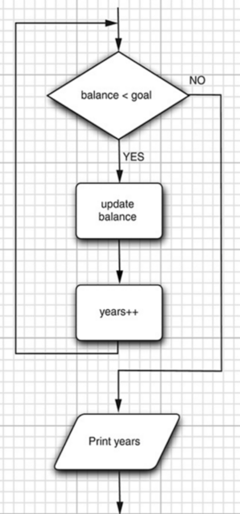

```java
double balance = 0;
double goal = 1000;
int years = 0;

while (balance < goal) {
    balance += 100;
    years++;
}

System.out.println("You need " + years + " years.")
```

```
You need 10 years.
```

If you want the block of code to execute at least once you need do use do-while loop. Its syntax looks like this: `do statement while (condition);`

```java
do {
    System.out.println("Inside do block");
} while (false);
System.out.println("Outside do-while block");
```

```
Inside do block
Outside do-while block
```

### Determinate loops

The for loop is a general construct to support iteration controlled by a counter or similar variable that is updated after every iteration. The syntax for the for loop is following: `for(initialization; condition; iteration) { block of code }`

```java
for (int i = 0; i < 10; i++) {
    System.out.println("Hello");
}
```

```
Hello
Hello
Hello
Hello
Hello
Hello
Hello
Hello
Hello
Hello
```

You can skip any step of *for* expression. For example:

```java
for (int i = 0; i < 10; ) {
    System.out.println(i);
    i++;
}
```

```
0
1
2
3
4
5
6
7
8
9
```

The following code is also valid. It creates an infinite loop.

```
for (;;) {
    Do something
}
```

Infinite loop also can be created using **while**:

```
while (true) {
do something
}
```

**for** loops really often used for counting tasks:

```java
public class ListCharacters {
    public static void main(String... args) {
        for (char c = 0; c < 128; c++) {
            if (Character.isLowerCase(c)) {
                System.out.println("value: " + (int)c + "\n" + "character: " + c);
            }
        }
    }
}
```

```java
ListCharacters.main()
```

```
value: 97
character: a
value: 98
character: b
value: 99
character: c
value: 100
character: d
value: 101
character: e
value: 102
character: f
value: 103
character: g
value: 104
character: h
value: 105
character: i
value: 106
character: j
value: 107
character: k
value: 108
character: l
value: 109
character: m
value: 110
character: n
value: 111
character: o
value: 112
character: p
value: 113
character: q
value: 114
character: r
value: 115
character: s
value: 116
character: t
value: 117
character: u
value: 118
character: v
value: 119
character: w
value: 120
character: x
value: 121
character: y
value: 122
character: z
```

### The Comma Operator

The comma operator(not the comma separator) has only one use in Java. In the control expression of the for loop. In both the initialization and step portions of the control expression, you can have a number of statements separated by commas, and those statements are evaluated sequentially. Using the comma operator, you can define multiple variables within a for statement, but they must be of the same type:

```java
for (int i = 1, j = i + 10; i < 5; i++, j += i) {
    System.out.println("i = " + i + " j = " + j);
}
```

```
i = 1 j = 11
i = 2 j = 13
i = 3 j = 16
i = 4 j = 20
```

### For-in syntax

Java 5 introduced a more succinct **for** syntax, for use with arrays and collections. This is sometimes called the enhanced **for** or **foreach**. The for-in produces each item for you, automatically, so you don’t create an int to count through a sequence of items. For example, suppose you have an array of float and you’d like to select each element in that array:

```java
Random r = new Random(47);
float[] floatArr = new float[10];
for (int i = 0; i < floatArr.length; i++) {
    floatArr[i] = r.nextFloat();
}

for (float f : floatArr) {
    System.out.println(f);
}
```

```
0.72711575
0.39982635
0.5309454
0.0534122
0.16020656
0.57799757
0.18847865
0.4170137
0.51660204
0.73734957
```

### Return

Several keywords represent unconditional branching , which means the branch happens without any test. These include return , break , continue , and a way to jump to a labeled statement, similar to goto in other languages. The return keyword has two purposes: It specifies what value a method will return (if it doesn’t have a void return value) and it causes the current method to exit, returning that value.

```java
public class TestWithReturn {
    static int test (int testval, int target) {
        if (testval > target) return + 1;
        if (testval < target) return - 1;
        return 0 ; // Match
    }

    public static void main (String[] args) {
        System.out.println(test(10, 5));
        System.out.println(test(5, 10));
        System.out.println(test(5, 5));
    }
}
```

```java
TestWithReturn.main(new String[]{});
```

```
1
-1
0
```

There’s no need for else, because the method will not continue after executing a return. If you do not have a return statement in a method that returns void, there’s an implicit return at the end of that method, so it’s not always necessary to include a return statement. However, if your method states it will return anything other than void, you must ensure every code path will return a value.

### Break and Continue

You can also control the flow of the loop inside the body of any of the iteration statements by using **break** and **continue**. **break** exits the loop without executing the rest of the statements in the loop. **continue** stops the execution of the current iteration and goes back to the beginning of the loop to begin the next iteration.

```java
public class BreakAndCondinue {
    public static void main(String... args) {
        for (int i = 0; i < 100; i++) {
            if (i == 74) break;
            if (i % 9 != 0) continue;
            System.out.print(i + " ");
        }
        System.out.println();
    }
}
```

```java
BreakAndCondinue.main()
```

```
0 9 18 27 36 45 54 63 72
```

The value of i never gets to 100 because the break statement breaks out of the loop when i is 74. Normally, you use a break like this only if you don’t know when the terminating condition occurs. The continue statement takes execution back to the top of the iteration loop (thus incrementing i ) whenever i is not evenly divisible by 9. When it is, the value is displayed.

### The Infamouse "goto"

The goto keyword was present in programming languages from the beginning. Indeed, goto was the genesis of program control in assembly language : “If condition A, then jump here; otherwise, jump there.” A goto is a jump at the source-code level, and that’s what brought it into disrepute. If a program will always jump from one point to another, isn’t there some way to reorganize the code so the flow of control is not so jumpy? goto fell into true disfavor with the publication of the famous “Goto considered harmful” paper by Edsger Dijkstra, and since then goto -bashing is a popular sport, with advocates of the cast-out keyword scurrying for cover. Although goto is a reserved word in Java, it is not used in the language—Java has no goto. However, it does have something that looks a bit like a jump tied in with the break and continue keywords. It’s not a jump but rather a way to break out of an iteration statement. The reason it’s often thrown in with discussions of goto is because it uses the same mechanism: a label. A label is an identifier followed by a colon, like this: `label1:`

The only place a label is useful in Java is right before an iteration statement. And that means right before—it does no good to put any other statement between the label and the iteration.

```
label1: outer-iteration {
    inner-iteration {
    // ...
    break; // [1]
    // ...
    continue; // [2]
    // ...
    continue label1; // [3]
    // ...
    break label1; // [4] }
}
```

[1] The break breaks out of the inner iteration and you end up in the outer iteration.  
[2] The continue moves back to the beginning of the inner iteration.  
[3] The continue label1 breaks out of the inner iteration and the outer iteration, all the way back to label1 . Then it does in fact continue the iteration, but starting at the outer iteration.  
[4] The break label1 also breaks all the way out to label1 , but it does not reenter the iteration. It actually does break out of both iterations.

**It’s important to remember that the only reason to use labels in Java is when you have nested loops and you must break or continue through more than one nested level.**

### Switch

The switch is sometimes called a selection statement . A switch selects from among pieces of code based on the value of an integral expression. Its general form is:

```
switch (integral-selector) {
    case integral-value1: statement; break;
    case integral-value2: statement; break;
    case integral-value3: statement; break;
    case integral-value4: statement; break;
    case integral-value5: statement; break;
    // ...
    default statement;
}
```

Integral-selector is an expression that produces an integral value. The switch compares the result of integral-selector to each integral-value . If it finds a match, the corresponding statement (a single statement or multiple statements; braces are not required) executes. If no match occurs, the default statement executes.  
The switch statement is a clean way to implement multiway selection

Here’s an example that creates letters randomly and determines whether they’re vowels or consonants:

```java
import java.util.*;

public class VowelsAndConsonants {
    public static void main(String... args) {
        Random rand = new Random(47);
        for (int i = 0; i < 100; i++) {
            int c = rand.nextInt(26) + 'a';
            System.out.print((char)c + ", " + c + ": ");
            switch(c) {
                case 'a':
                case 'e':
                case 'i':
                case 'o':
                case 'u':
                    System.out.println("Vowel");
                    break;
                case 'y':
                case 'w':
                    System.out.println("Sometimes vowel");
                    break;
                default:
                    System.out.println("Consonant");
            }
        }
    }
}
```

```java
VowelsAndConsonants.main()
```

```
y, 121: Sometimes vowel
n, 110: Consonant
z, 122: Consonant
b, 98: Consonant
r, 114: Consonant
n, 110: Consonant
y, 121: Sometimes vowel
g, 103: Consonant
c, 99: Consonant
f, 102: Consonant
o, 111: Vowel
w, 119: Sometimes vowel
z, 122: Consonant
n, 110: Consonant
t, 116: Consonant
c, 99: Consonant
q, 113: Consonant
r, 114: Consonant
g, 103: Consonant
s, 115: Consonant
e, 101: Vowel
g, 103: Consonant
z, 122: Consonant
m, 109: Consonant
m, 109: Consonant
j, 106: Consonant
m, 109: Consonant
r, 114: Consonant
o, 111: Vowel
e, 101: Vowel
s, 115: Consonant
u, 117: Vowel
e, 101: Vowel
c, 99: Consonant
u, 117: Vowel
o, 111: Vowel
n, 110: Consonant
e, 101: Vowel
o, 111: Vowel
e, 101: Vowel
```

[output cut: 45 more lines]

```
z, 122: Consonant
d, 100: Consonant
y, 121: Sometimes vowel
c, 99: Consonant
y, 121: Sometimes vowel
r, 114: Consonant
f, 102: Consonant
j, 106: Consonant
q, 113: Consonant
a, 97: Vowel
h, 104: Consonant
x, 120: Consonant
x, 120: Consonant
h, 104: Consonant
v, 118: Consonant
```

### Switch with Strings

Java 7 added the ability to switch on Strings as well as integer values. The see the next example:

```java
public class SwitchStrings {
    public static void main(String... args) {
        String color = "green";
        // Old way using if-else
        if ("red".equals(color)) {
            System.out.println("RED");
        } else if ("green".equals(color)) {
            System.out.println("GREEN");
        } else if ("blue".equals("color")) {
            System.out.println("BLUE");
        } else if ("yellow".equals(color)) {
            System.out.print("YELLOW");
        } else {
            System.out.println("Unknown");
        }
        // New way: String in switch
        switch(color) {
            case "red":
                System.out.println("RED");
                break;
            case "green":
                System.out.println("GREEN");
                break;
            case "blue":
                System.out.println("BLUE");
                break;
            case "yellow":
                System.out.print("YELLOW");
                break;
            default:
                System.out.println("Unknown");
        }
    }
}
```

```java
SwitchStrings.main()
```

```
GREEN
GREEN
```

You can use switch statements with enums. This is very useful tool in a toolbox.

```java
public enum Size {
    S, M, L, XL, NONE
}
```

```java
Size size = Size.NONE;

switch (size) {
    case S:
        System.out.println("SMALL");
        break;
    case M:
        System.out.println("MEDIUM");
        break;
    case L:
        System.out.println("LARGE");
        break;
    case XL:
        System.out.println("EXTRA LARGE");
        break;
    default:
        System.out.println("No such size");
}
```

```
No such size
```